# Data Commons Data Sets

Prof. Gareth W. Peters

2023-01-08

# Data Commons Data

The Data Commons Data website is a rich source of time series data

- https://datacommons.org/

The Data Commons knowledge graph is huge – there are over 240B data points for over 120K statistical variables.

Sometimes, you may want to export just some of this data and use it in a custom tool.

They make that easy to do with the new data download tool.

The new tool gives you the data in a csv file, does not require any coding experience to use, and allows you to select the statistical variables, places, and dates that you are interested in.

Maybe you want to explore the population of all the countries in the world:

- https://datacommons.org/tools/download#pt=Country&place=Earth&sv=Count_Person&dtType=LATEST&facets=%7B%7D

Can see that this allows you to select a date period (I selected ALL Available Dates) then downloaded a csv file: Earth_Country.csv

Or you want to analyze poverty levels during COVID-19

- https://datacommons.org/tools/download#pt=State&place=country%2FUSA&sv=Count_Person_BelowPovertyLevelInThePast12Months__CumulativeCount_MedicalConditionIncident_COVID_19_ConfirmedOrProbableCase&dtType=RANGE&facets=%7B%7D&dtMin=2020&dtMax=2021

Or you’re interested in projected temperature differences and activities that can be affected by temperature rise

- https://datacommons.org/tools/download#pt=County&place=country%2FUSA&sv=DifferenceRelativeToBaseDate2006_Max_Temperature_RCP45__Percent_Person_WithCoronaryHeartDisease__WithdrawalRate_Water__Area_Farm_IrrigatedLand&dtType=LATEST&facets=%7B%7D

The Data Download tool gives you the power to use the data in our knowledge graph to explore all of this and much more in your tool of choice.

[figure not shown]

Image of Data Commons Home Page

They have a fantastic data download tool:

- https://datacommons.org/tools/download

Example of fertility data:

- https://datacommons.org/browser/country/USA

It also allows you to see a table format or a time series plot (chart)

https://docs.datacommons.org/2022/09/14/download-tool.html

# Read in the Data from Data commons CSV

```r
Earth_Population_Yearly <- readr::read_csv("Earth_Country.csv",show_col_types = FALSE)
head(Earth_Population_Yearly)
```

```
## # A tibble: 6 × 5
##   placeDcid   placeName `Date:Count_Person` `Value:Count_Person` Source:Count_…¹
##   <chr>       <chr>                   <dbl>                <dbl> <chr>
## 1 country/ABW Aruba                    1960                54208 https://dataca…
## 2 country/ABW Aruba                    1961                55434 https://dataca…
## 3 country/ABW Aruba                    1962                56234 https://dataca…
## 4 country/ABW Aruba                    1963                56699 https://dataca…
## 5 country/ABW Aruba                    1964                57029 https://dataca…
## 6 country/ABW Aruba                    1965                57357 https://dataca…
## # … with abbreviated variable name ¹`Source:Count_Person`
```

What countries are included

- We can use the unique() function on the field placeName

```r
unique(Earth_Population_Yearly$placeName)
```

```
##   [1] "Aruba"
##   [2] "Afghanistan"
##   [3] "Angola"
##   [4] "Anguilla"
##   [5] "Albania"
##   [6] "Andorra"
##   [7] "Netherlands Antilles"
##   [8] "United Arab Emirates"
##   [9] "Argentina"
##  [10] "Armenia"
##  [11] "American Samoa"
##  [12] "French Southern Territories"
##  [13] "Antigua and Barbuda"
##  [14] "Australia"
##  [15] "Austria"
```

[output cut: 233 more lines]

Lets select all the data for a given country say United States of America

```r
USA_Population_Yearly_df <- as.data.frame(Earth_Population_Yearly) %>% select(c('placeName','Date:Count_Person','Value:Count_Person')) %>% filter(placeName == 'United States of America')
```

We can then make a summary of this data

```r
summary(USA_Population_Yearly_df)
```

```
##   placeName         Date:Count_Person Value:Count_Person
##  Length:122         Min.   :1900      Min.   : 76094000
##  Class :character   1st Qu.:1930      1st Qu.:123317468
##  Mode  :character   Median :1960      Median :182181320
##                     Mean   :1960      Mean   :189938523
##                     3rd Qu.:1991      3rd Qu.:252652351
##                     Max.   :2021      Max.   :331893745
```

We can plot the change in the population Year over Year for the USA as follows

- Time Series Plot

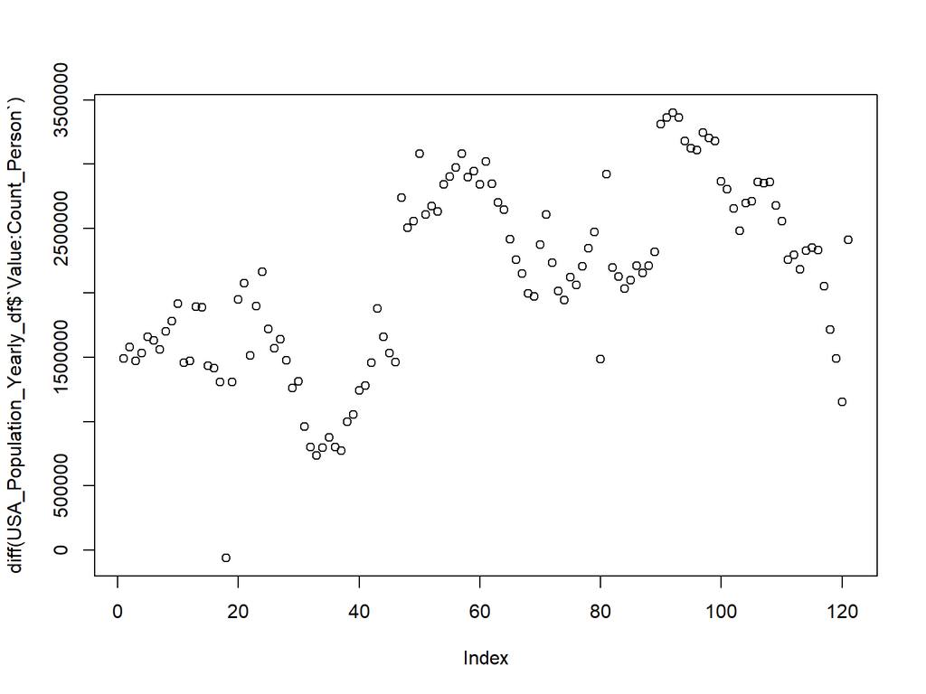

```r
plot(diff(USA_Population_Yearly_df$`Value:Count_Person`))
```